# Session 4: Homework 2

Study Group B12; Jay Bansal, Jiacheng Zhu, Chloe Baubier, Utku Odabasi, Yaxin Lyu, Mengtian Li

2021-10-03

```r
knitr::opts_chunk$set(
  message = FALSE,
  warning = FALSE,
  tidy=FALSE,     # display code as typed
  size="small")   # slightly smaller font for code
options(digits = 3)

# default figure size
knitr::opts_chunk$set(
  fig.width=6.75,
  fig.height=6.75,
  fig.align = "center"
)
```

```r
library(tidyverse)  # Load ggplot2, dplyr, and all the other tidyverse packages
library(mosaic)
library(ggthemes)
library(lubridate)
library(here)
library(skimr)
library(janitor)
library(httr)
library(readxl)
library(vroom)
library(tidyquant)
library(rvest)
library(scales)
library(infer)
```

# 1 Climate change and temperature anomalies

```r
# Load the file
weather <-
  read_csv("https://data.giss.nasa.gov/gistemp/tabledata_v4/NH.Ts+dSST.csv",
           skip = 1,
           na = "***")
```

```r
tidyweather <- weather %>%
    select(1:13) %>%
    pivot_longer(cols=2:13, names_to="month", values_to = "delta")

tidyweather
```

```
## # A tibble: 1,704 x 3
##     Year month delta
##    <dbl> <chr> <dbl>
##  1  1880 Jan   -0.34
##  2  1880 Feb   -0.5
##  3  1880 Mar   -0.22
##  4  1880 Apr   -0.29
##  5  1880 May   -0.05
##  6  1880 Jun   -0.15
##  7  1880 Jul   -0.17
##  8  1880 Aug   -0.25
##  9  1880 Sep   -0.22
## 10  1880 Oct   -0.31
## # ... with 1,694 more rows
```

## 1.1 Plotting Information

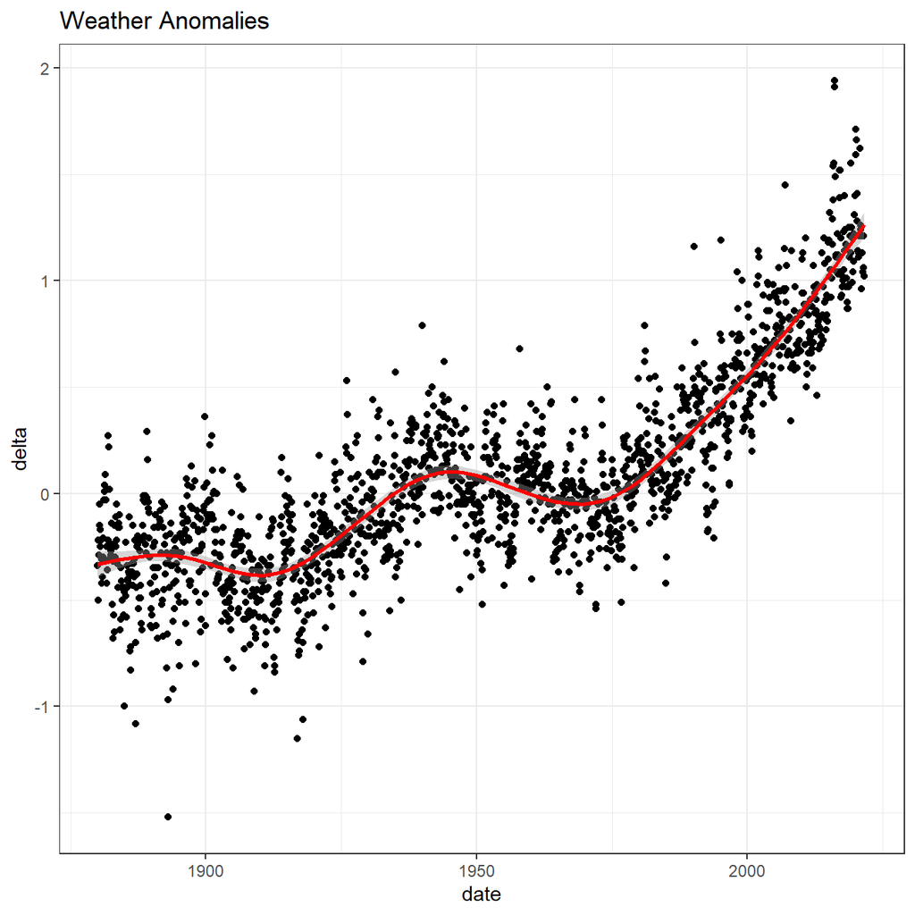

```r
# Plot the data using a time-series scatter plot, and add a trendline
tidyweather <- tidyweather %>%
  mutate(date = ymd(paste(as.character(Year), month, "1")),
         month = month(date, label=TRUE),
         year = year(date))

ggplot(tidyweather, aes(x=date, y = delta))+
  geom_point()+
  geom_smooth(color="red") +
  theme_bw() +
  labs (
    title = "Weather Anomalies")
```

Is the effect of increasing temperature more pronounced in some months?

The effect of increasing temperature seem to be more pronounced especially during the winter period, for the months of December, February, January, and March.

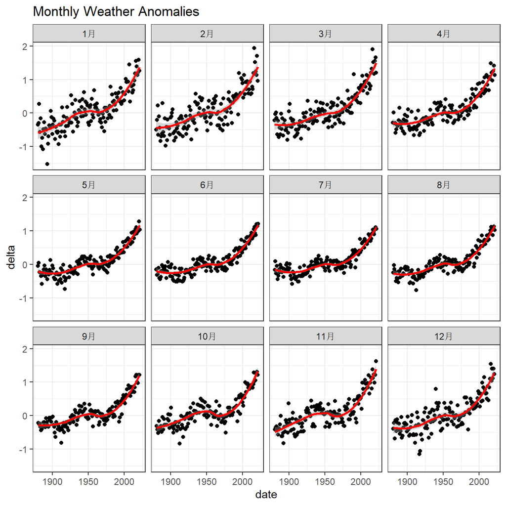

```r
ggplot(tidyweather, aes(x=date, y = delta)) +
  geom_point() +
  geom_smooth(color="red") +
  theme_bw() +
  labs (title = "Monthly Weather Anomalies") +
  facet_wrap("month")
```

```r
comparison <- tidyweather %>%
  filter(Year>= 1881) %>%     #remove years prior to 1881
  mutate(interval = case_when(
    Year %in% c(1881:1920) ~ "1881-1920",
    Year %in% c(1921:1950) ~ "1921-1950",
    Year %in% c(1951:1980) ~ "1951-1980",
    Year %in% c(1981:2010) ~ "1981-2010",
    TRUE ~ "2011-present"
  ))
```

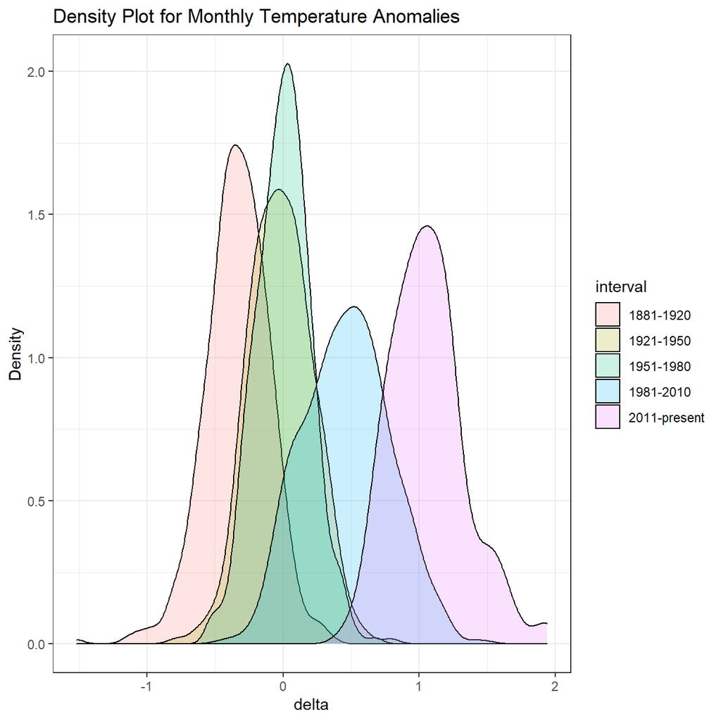

```r
ggplot(comparison, aes(x=delta, fill=interval))+
  geom_density(alpha=0.2) +   #density plot with tranparency set to 20%
  theme_bw() +                #theme
  labs (
    title = "Density Plot for Monthly Temperature Anomalies",
    y     = "Density"         #changing y-axis label to sentence case
  )
```

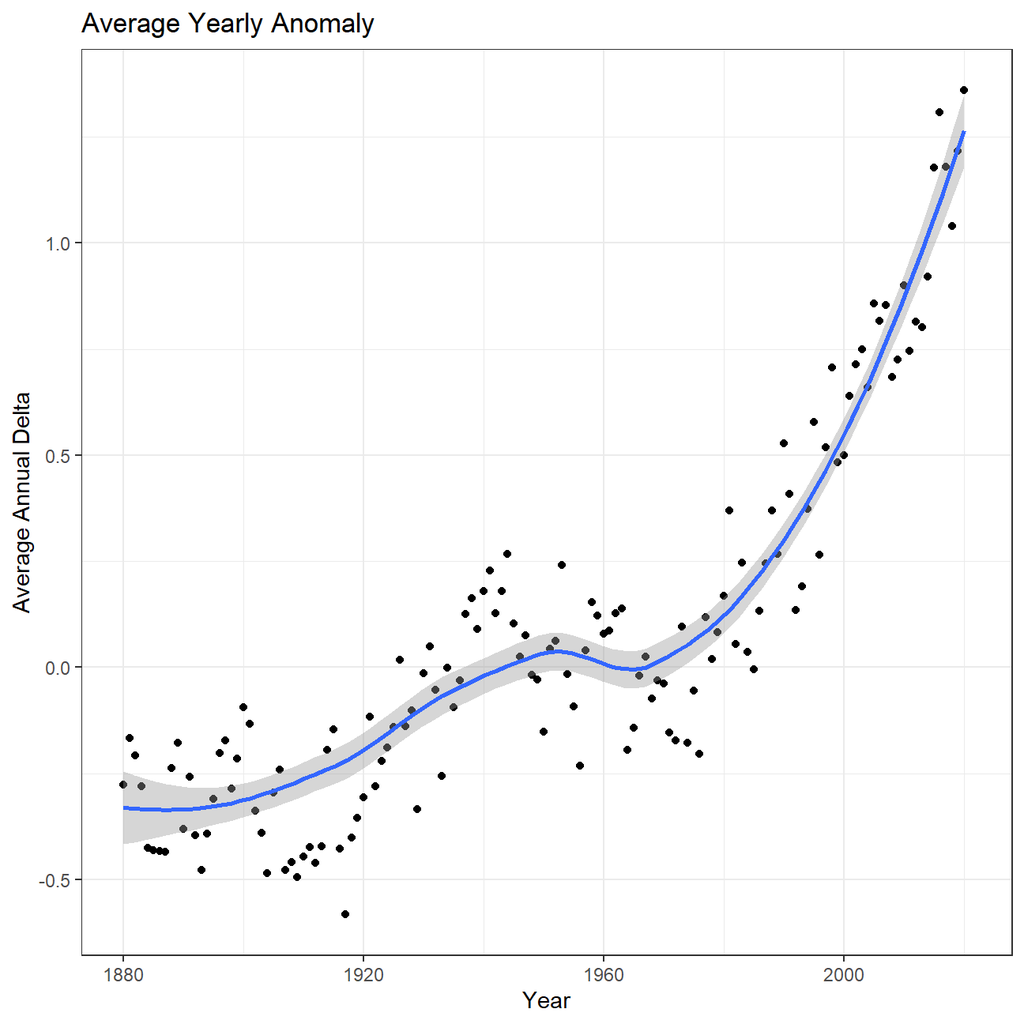

```r
#creating yearly averages
average_annual_anomaly <- tidyweather %>%
  group_by(Year) %>%
   summarise(annual_average_delta = mean(delta),  na.rm = TRUE)

#plotting the data:
ggplot(average_annual_anomaly, aes(x=Year, y= annual_average_delta))+
  geom_point()+
  geom_smooth() +
  theme_bw() +
  labs (
    title = "Average Yearly Anomaly",
    y     = "Average Annual Delta"
  )
```

## 1.2 Confidence Interval for `delta`

```r
# Construct a confidence interval for the average annual delta since 2011

# We are not using 'comparison' data here because it gives all monthly delta - not annual averages. We want CI for average annual delta!

formula_ci <- average_annual_anomaly %>%
  filter(Year>=2011)%>%
  summarise(mean = mean(annual_average_delta,  na.rm = TRUE),
            SD = sd(annual_average_delta, na.rm = TRUE),
            count=n(),
            SE = SD/sqrt(count),
            t_critical = qt(0.975, count-1),
            errormargin = t_critical * SE,
            lower = mean - errormargin,
            upper = mean + errormargin)

formula_ci
```

```
## # A tibble: 1 x 8
##    mean    SD count     SE t_critical errormargin lower upper
##   <dbl> <dbl> <int>  <dbl>      <dbl>       <dbl> <dbl> <dbl>
## 1  1.06 0.224    11 0.0674       2.23       0.150 0.906  1.21
```

```r
set.seed(505)

bootstrap_delta <- average_annual_anomaly %>%
  filter(Year>=2011)%>%
  specify(response = annual_average_delta ) %>%
  generate (reps = 1000, type = "bootstrap") %>%
  calculate(stat ="mean")

bootstrap_ci <- bootstrap_delta %>%
  get_confidence_interval(level=0.95, type = "percentile")

bootstrap_ci
```

```
## # A tibble: 1 x 2
##   lower_ci upper_ci
##      <dbl>    <dbl>
## 1    0.927     1.19
```

# 2 Global warming and political views (GSS)

```r
global_warming_pew <- read_csv(here::here("data", "global_warming_pew.csv"))
global_warming1 <- global_warming_pew[!(global_warming_pew$response == "Don't know / refuse to answer"),]
global_warming1
```

```
## # A tibble: 2,117 x 2
##    party_or_ideology       response
##    <chr>                   <chr>
##  1 Conservative Republican Earth is warming
##  2 Conservative Republican Earth is warming
##  3 Conservative Republican Earth is warming
##  4 Conservative Republican Earth is warming
##  5 Conservative Republican Earth is warming
##  6 Conservative Republican Earth is warming
##  7 Conservative Republican Earth is warming
##  8 Conservative Republican Earth is warming
##  9 Conservative Republican Earth is warming
## 10 Conservative Republican Earth is warming
## # ... with 2,107 more rows
```

```r
global_warming1 %>%
  count(party_or_ideology, response)
```

```
## # A tibble: 8 x 3
##   party_or_ideology       response             n
##   <chr>                   <chr>            <int>
## 1 Conservative Republican Earth is warming   248
## 2 Conservative Republican Not warming        450
## 3 Liberal Democrat        Earth is warming   405
## 4 Liberal Democrat        Not warming         23
## 5 Mod/Cons Democrat       Earth is warming   563
## 6 Mod/Cons Democrat       Not warming        158
## 7 Mod/Lib Republican      Earth is warming   135
## 8 Mod/Lib Republican      Not warming        135
```

Many responses should not be taken into consideration, such as “No Answer”, “Don’t Know”, “Not applicable”, “Refused to Answer”.

```r
global_warming1 %>%
  count(party_or_ideology, response)
```

```
## # A tibble: 8 x 3
##   party_or_ideology       response             n
##   <chr>                   <chr>            <int>
## 1 Conservative Republican Earth is warming   248
## 2 Conservative Republican Not warming        450
## 3 Liberal Democrat        Earth is warming   405
## 4 Liberal Democrat        Not warming         23
## 5 Mod/Cons Democrat       Earth is warming   563
## 6 Mod/Cons Democrat       Not warming        158
## 7 Mod/Lib Republican      Earth is warming   135
## 8 Mod/Lib Republican      Not warming        135
```

```r
prop.test(248,698)
```

```
##
##  1-sample proportions test with continuity correction
##
## data:  248 out of 698
## X-squared = 58, df = 1, p-value = 3e-14
## alternative hypothesis: true p is not equal to 0.5
## 95 percent confidence interval:
##  0.320 0.392
## sample estimates:
##     p
## 0.355
```

```r
prop.test(405,428)
```

```
##
##  1-sample proportions test with continuity correction
##
## data:  405 out of 428
## X-squared = 339, df = 1, p-value <2e-16
## alternative hypothesis: true p is not equal to 0.5
## 95 percent confidence interval:
##  0.919 0.965
## sample estimates:
##     p
## 0.946
```

```r
prop.test(563,721)
```

```
##
##  1-sample proportions test with continuity correction
##
## data:  563 out of 721
## X-squared = 226, df = 1, p-value <2e-16
## alternative hypothesis: true p is not equal to 0.5
## 95 percent confidence interval:
##  0.748 0.810
## sample estimates:
##     p
## 0.781
```

```r
prop.test(135,270)
```

```
##
##  1-sample proportions test without continuity correction
##
## data:  135 out of 270
## X-squared = 0, df = 1, p-value = 1
## alternative hypothesis: true p is not equal to 0.5
## 95 percent confidence interval:
##  0.441 0.559
## sample estimates:
##   p
## 0.5
```

Does it appear that whether or not a respondent believes the earth is warming is independent of their party ideology?

Liberal Democrats as well as Mod/Cons Democrats tend to believe the Earth is warming, while Conservative Republicans do not believe the Earth is warming. Therefore, their belief are not independent of party ideology. However, among Mod/Lib Republicans, their belief on whether the earth is warming is generally independent of their party ideology.

# 3 Biden’s Approval Margins

```r
# Import approval polls data directly off fivethirtyeight website
approval_polllist <- read_csv('https://projects.fivethirtyeight.com/biden-approval-data/approval_polllist.csv')

approval_polllist <- approval_polllist %>%
mutate(
enddate=mdy(enddate),
week=week(enddate),
)
# Use `lubridate` to fix dates, as they are given as characters.
```

## 3.1 Create a plot

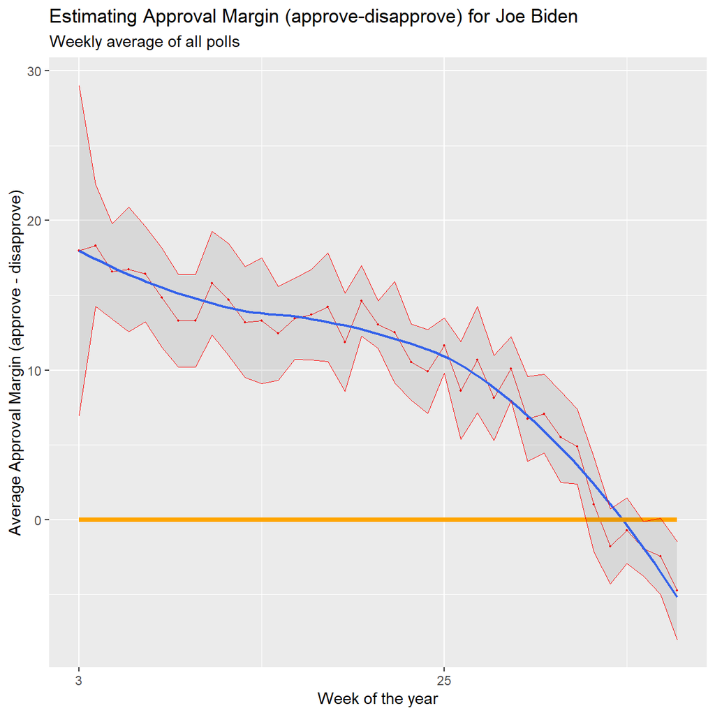

```r
approval_polllist %>%
  filter(subgroup == 'All polls') %>%
  group_by(week) %>%
  summarise(
    av_net_approval_rate=mean(approve-disapprove),
    sd_net_approval_rate = sd(approve-disapprove),
    count = n(),
    se_net_approval_rate = sd_net_approval_rate/ sqrt(count),
    # Get interval upper and lower values
    t_critical = qt(0.975, count - 1 ),
    lower = av_net_approval_rate - t_critical * se_net_approval_rate,
    upper = av_net_approval_rate + t_critical * se_net_approval_rate
  ) %>%

  ggplot(aes(x=week, y=av_net_approval_rate))+
geom_line(color="red",size=0.3)+
geom_point(color="red",size=0.3)+
geom_smooth(size=0.8,method = 'loess',  se=FALSE)+
geom_line(aes(x=week, y=0),color="orange",size=1.5)+
geom_ribbon(aes(ymin=lower,ymax=upper),alpha=0.1,color="red",size=0.2)+
scale_x_continuous(breaks=c(3,25))+
labs(title="Estimating Approval Margin (approve-disapprove) for Joe Biden", subtitle= "Weekly average of all polls",x="Week of the year", y= "Average Approval Margin (approve - disapprove)")
```

## 3.2 Compare Confidence Intervals

Compare the confidence intervals for `week 3` and `week 25`. Can you explain what’s going on? One paragraph would be enough.

The confidence interval at week 3 is a lot wider than the one at week 25. This is merely due to statistical reason which is related to the number of polls executed at those times. At week 3, only 5 polls were executed whereas at week 25, 29 pools were done. Mechanically, the standard errors is lower for week 25 than week 3 which narrows the confidence interval.

# 4 Challenge 1: Excess rentals in TfL bike sharing

```r
url <- "https://data.london.gov.uk/download/number-bicycle-hires/ac29363e-e0cb-47cc-a97a-e216d900a6b0/tfl-daily-cycle-hires.xlsx"

# Download TFL data to temporary file
httr::GET(url, write_disk(bike.temp <- tempfile(fileext = ".xlsx")))
```

```
## Response [https://airdrive-secure.s3-eu-west-1.amazonaws.com/london/dataset/number-bicycle-hires/2021-09-23T12%3A52%3A20/tfl-daily-cycle-hires.xlsx?X-Amz-Algorithm=AWS4-HMAC-SHA256&X-Amz-Credential=AKIAJJDIMAIVZJDICKHA%2F20211003%2Feu-west-1%2Fs3%2Faws4_request&X-Amz-Date=20211003T215830Z&X-Amz-E…
##   Date: 2021-10-03 21:58
##   Status: 200
##   Content-Type: application/vnd.openxmlformats-officedocument.spreadsheetml.sheet
##   Size: 174 kB
## <ON DISK>  C:\Users\rsm\AppData\Local\Temp\RtmpWKxZYM\file28cc59ed772e.xlsx
```

```r
# Use read_excel to read it as dataframe
bike0 <- read_excel(bike.temp,
                   sheet = "Data",
                   range = cell_cols("A:B"))

# change dates to get year, month, and week
bike <- bike0 %>%
  clean_names() %>%
  rename (bikes_hired = number_of_bicycle_hires) %>%
  mutate (year = year(day),
          month = lubridate::month(day, label = TRUE),
          week = isoweek(day))
```

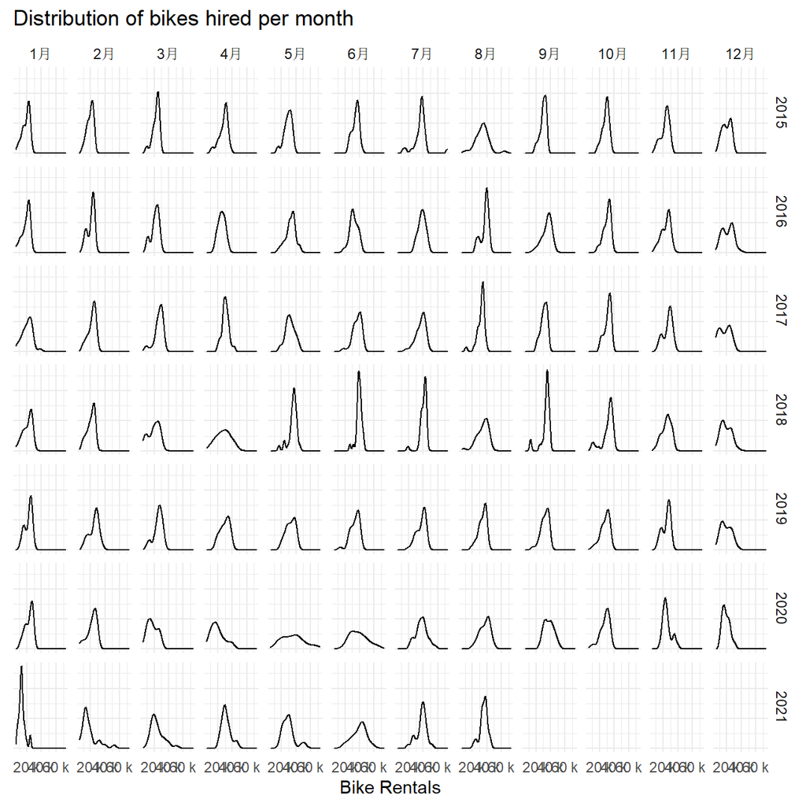

```r
bike %>%
  filter(year >2014) %>%

  ggplot(aes(x = bikes_hired)) +
  geom_density() +
  labs(title = 'Distribution of bikes hired per month',x = 'Bike Rentals')+
  facet_grid(rows = vars(year),cols = vars(month))+
  theme_minimal() +
  theme(legend.position = 'none')+
  theme(axis.text.y = element_blank())+
  theme(panel.border = element_blank())+
  theme(axis.ticks.y = element_blank())+
  theme(axis.ticks.x = element_blank())+

  scale_x_continuous(labels = scales::unit_format(unit = 'k',scale=1e-3) ) +
  ylab(NULL)
```

Look at May and Jun and compare 2020 with the previous years. What’s happening?

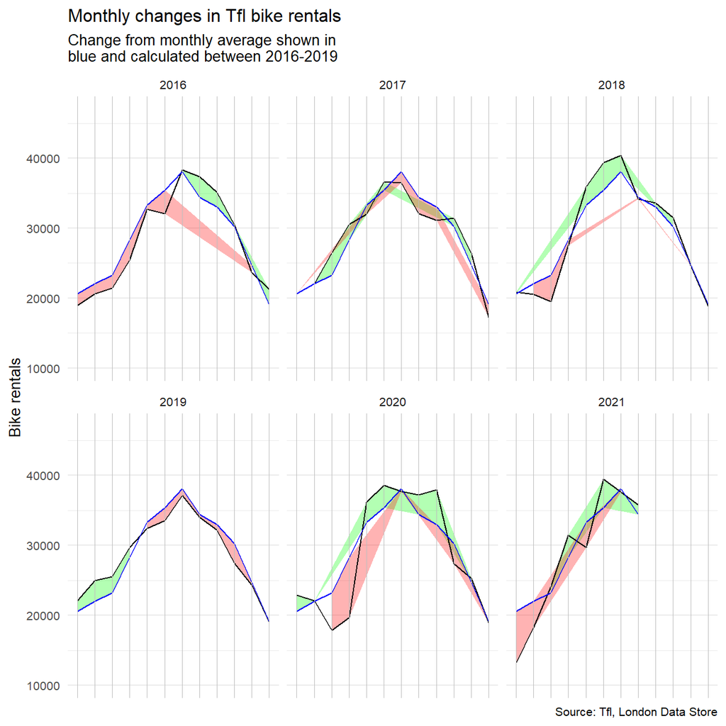

```r
#get average monthly data
bike_monthly_average<- bike %>%
  filter(year>=2016) %>%
  filter(year<=2019) %>%
  group_by(month) %>%
  summarise(monthly_average = mean(bikes_hired))

#merge average monthly data with bike data frame
merged_bike <- bike %>%
  left_join(bike_monthly_average,by="month") %>%
  mutate(month = month(day))

#Calculate the difference between the expected and actual
adjusted_merged_bike <- merged_bike %>%
  filter(year>=2016) %>%
  group_by(year,month) %>%
  summarise(bike_rentals = mean(bikes_hired),year=year,month=month,monthly_average=monthly_average) %>%
  mutate(difference = monthly_average - bike_rentals) %>%
  mutate(group=ifelse(difference <= 0, "A", "B") )

adjusted_merged_bike %>%
  ggplot(aes(x=month))+
  geom_ribbon(aes(ymin=bike_rentals,ymax=monthly_average,fill =group),alpha=0.3,size=0.2)+
  geom_line(aes(y=bike_rentals))+
  geom_line(aes(y=monthly_average),color="blue")+
  scale_x_continuous(breaks=NULL)+
  labs(title="Monthly changes in Tfl bike rentals",subtitle = "Change from monthly average shown in \nblue and calculated between 2016-2019",caption = "Source: Tfl, London Data Store")+
  scale_fill_manual(values=c("green", "red"), name="fill")+
  xlab(NULL) +
  ylab("Bike rentals")+
  theme_minimal()+
  theme(legend.position = "none",text = element_text(size=10))+
  geom_vline(xintercept = c(1,2,3,4,5,6,7,8,9,10,11,12),size=0.0001, color="gray")+
  ylim(10000,47000)+
  facet_wrap(~year)
```

The second one looks at percentage changes from the expected level of weekly rentals. The two grey shaded rectangles correspond to Q2 (weeks 14-26) and Q4 (weeks 40-52).

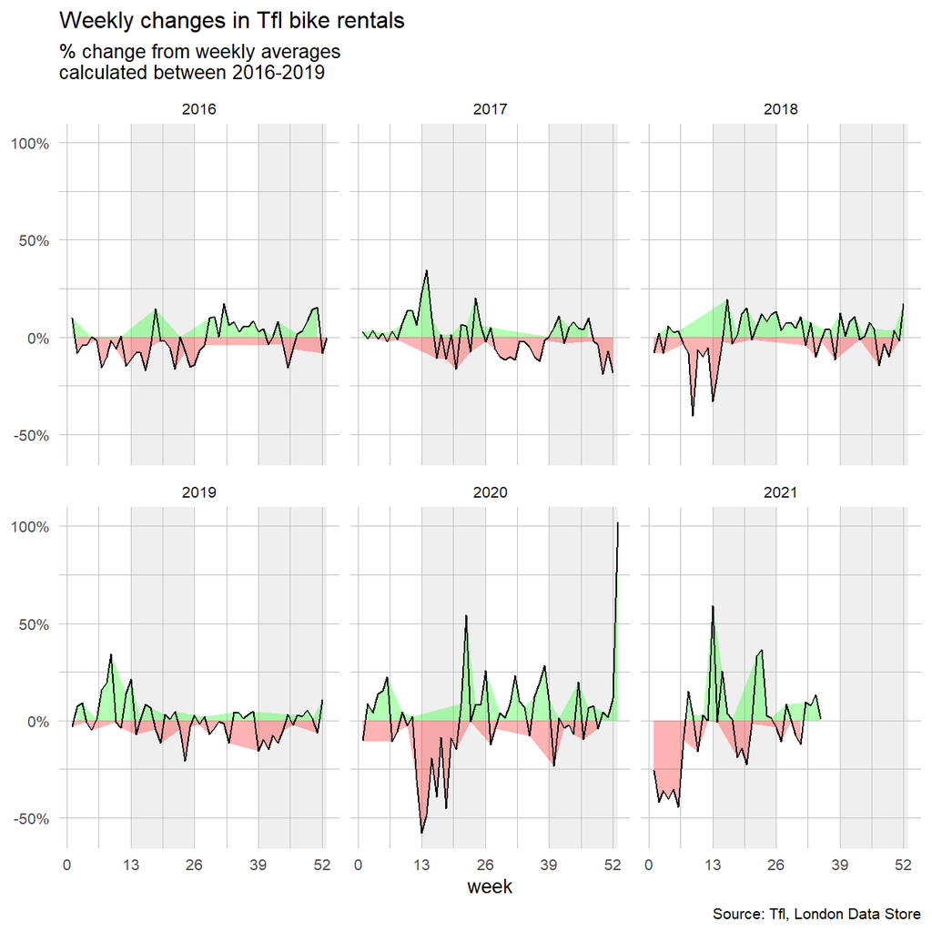

```r
#get average weekly data
bike_weekly_average<- bike %>%
  filter(year>=2016) %>%
  filter(year<=2019) %>%
  group_by(week) %>%
  summarise(weekly_average = mean(bikes_hired))

#merge average weekly data with bike data frame
merged_bike_weekly <- bike %>%
  left_join(bike_weekly_average,by="week")

#Calculate the difference in percentage from expected
adjusted_weekly_merged_bike <- merged_bike_weekly %>%
  filter(year>=2016) %>%
  group_by(year,week) %>%
  summarise(bike_rentals = mean(bikes_hired),year=year,week=week,weekly_average=weekly_average,) %>%
  mutate(percentage = (bike_rentals - weekly_average )/weekly_average )%>%
  mutate(group=ifelse(percentage <= 0, "A", "B") ) %>%
  arrange(desc(year))

adjusted_weekly_merged_bike%>%
  filter(year != 2021 | week != 53) %>%
  ggplot(aes(x=week))+
  annotate("rect", xmin=13, xmax=26, ymin=-Inf, ymax=Inf, alpha=0.25, fill="grey") +
  annotate("rect", xmin=39, xmax=53, ymin=-Inf, ymax=Inf, alpha=0.25, fill="grey") +
  geom_ribbon(aes(ymin=0,ymax=percentage,fill =group),alpha=0.3,size=0.2)+
  geom_line(aes(y=percentage))+
  scale_y_continuous(labels = scales::percent)+
  scale_x_continuous(breaks = seq(0, 54, by = 13))+
  labs(title="Weekly changes in Tfl bike rentals",subtitle = "% change from weekly averages \ncalculated between 2016-2019",caption = "Source: Tfl, London Data Store")+
  scale_fill_manual(values=c("red","green"), name="fill")+
  ylab(NULL) +
  xlab("week")+
  theme_minimal()+
  theme(panel.grid.major = element_line(size = 0.1, linetype = 'solid', colour = "grey"),
  panel.grid.minor = element_line(size = 0.1, linetype = 'solid', colour = "grey")) +
  theme(legend.position = "none",text = element_text(size=10))+
  facet_wrap(~year)
```

Should you use the mean or the median to calculate your expected rentals? Why?

Median is a better metric to use in order to avoid the effect of certain events such as the day where underground stopped working in London.

# 5 Challenge 2: How has the CPI and its components changed over the last few years?

[figure not shown]

```r
#Download relevant packages
library(rvest)
library(tidyverse)
library(tidyquant)
library(janitor)

# Get the url
url <- "https://fredaccount.stlouisfed.org/public/datalist/843"

# Get all the tables on the webpage
tables <- url %>%
  read_html() %>%
  html_table(fill=TRUE)

# Get the second table which contains data we are looking for - total CPI and its components
second_table <- tables[[2]] %>%
  clean_names()

# Get the series ids as vectors
component_series_id <- as_tibble(second_table) %>%
  pull(series_id)

# Create a list containing the component names and their seris ids
component_list <- tibble(components_id = component_series_id,
                         component_names = c("Airline Fares","Alcoholic Beverages at Home","Alcoholic Beverages Away from Home","Alcoholic Beverages","All Items","Apparel","Cereals and Bakery Products","Coffee","Dairy and Related Products","Electricity","Energy Services","Fats and Oils","Food and Beverages","Food at Home","Food Away from Home","Food","Footwear","Fruits and Vegetables","Fuel Oil and Other Fuels","Fuels and Utilities","Gasoline (All Types)","Household Energy","Household Furnishings and Operations","Housing","Infants' and Toddlers' Apparel","Lodging Away from Home","Meats, Poultry, Fish, and Eggs","Men's and Boys' Apparel","Motor Fuel","Motor Vehicle Maintenance and Repair","Motor Vehicle Parts and Equipment","New and Used Motor Vehicles","New Vehicles","Nonalcoholic Beverages and Beverages Materials","Other Food at Home","Other Food Away from Home","Other Foods","Owners' Equivalent Rent of Primary Residence","Owners' Equivalent Rent of Residences","Private Transportation","Public Transportation","Rent of Primary Residence","Consumers: Shelter","Sugar and Sweets","Transportation","Used Cars and Trucks","Utility (Piped) Gas Service","Water and Sewer and Trash Collection Services","Women's and Girls' Apparel"))

# Get all the data from the FRED webpage
component_list <- component_list %>%
  tq_get(get = "economic.data", from =  "2000-01-01") %>%
  mutate(year = year(date),
         yoy_change = price/lag(price, 12) - 1)

# Add a "PN" column addressing whether yoy_change is positive or negative
component_list <- component_list %>%
  mutate(PN = case_when(
    yoy_change > 0 ~ "Positive",
    yoy_change < 0 ~ "Negative"
  ))

# Plot the faceted scatter plots
ggplot(
  data = component_list,
  mapping = aes(
    x = year,
    y = yoy_change,
    color = PN)) +
  geom_point() +
  labs(title = "Yearly change of US CPI (All Items) and its components",
       subtitle = "YoY change being positive or negative") +
  scale_y_continuous(labels = scales::percent_format(accuracy = 0.1)) +
  geom_smooth(method = loess, size=0.5, colour="black") +
  theme_bw() +
  facet_wrap(~component_names, scales = "free") +
  theme(legend.position = "none")
```

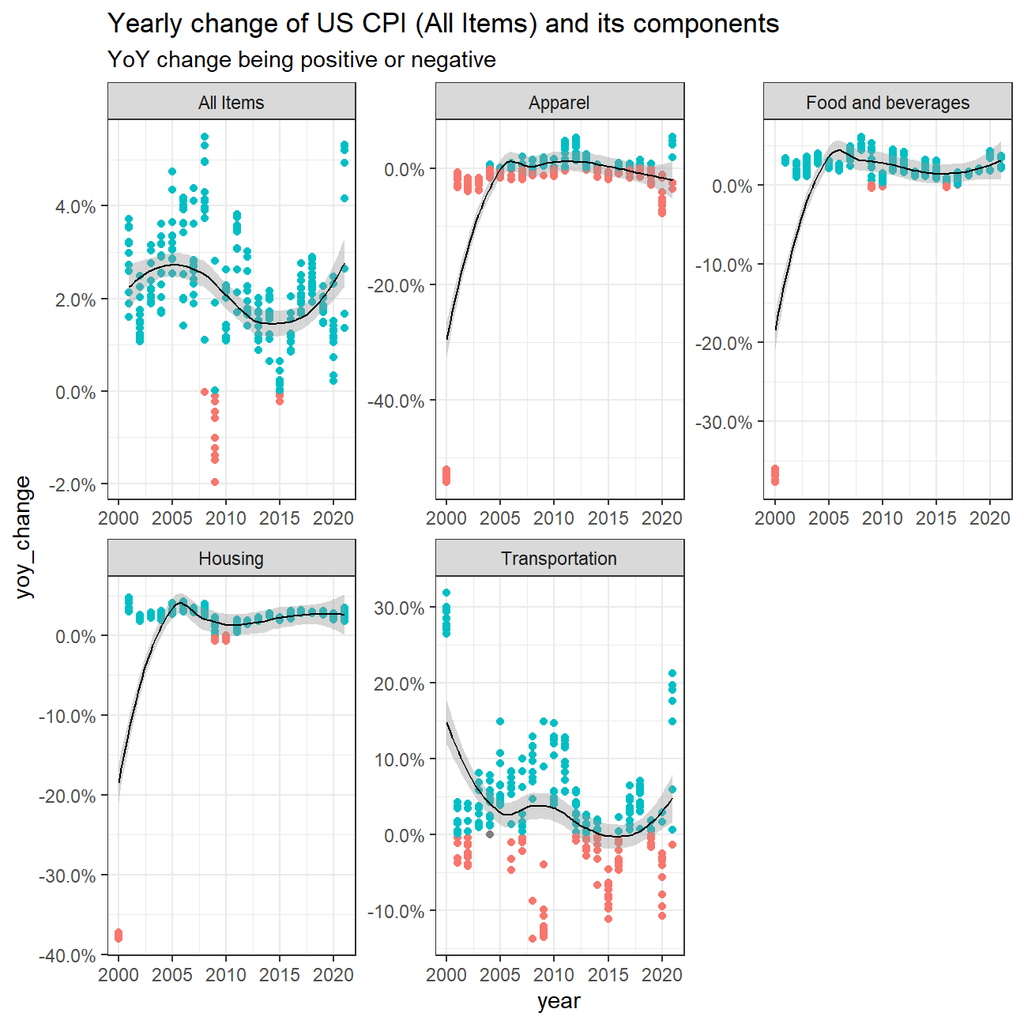

```r
# List sorted by relevant importance
component_list2 <- tibble(components_id = c("CPIAUCSL","CPIFABSL","CPIHOSSL","CPIAPPSL","CPITRNSL"), component_names = c("All Items","Food and beverages","Housing","Apparel","Transportation"))

# Get the data from the FRED webpage
component_list2 <- component_list2 %>%
  tq_get(get = "economic.data", from =  "2000-01-01") %>%
  mutate(year = year(date),
         yoy_change = price/lag(price, 12) - 1)

# Add a "PN" column addressing whether yoy_change is positive or negative
component_list2 <- component_list2 %>%
  mutate(PN = case_when(
    yoy_change > 0 ~ "Positive",
    yoy_change < 0 ~ "Negative"
  ))

# Plot the faceted scatter plots
ggplot(
  data = component_list2,
  mapping = aes(
    x = year,
    y = yoy_change,
    color = PN)) +
  geom_point() +
  labs(title = "Yearly change of US CPI (All Items) and its components",
       subtitle = "YoY change being positive or negative") +
  scale_y_continuous(labels = scales::percent_format(accuracy = 0.1)) +
  geom_smooth(method = loess, size=0.5, colour="black") +
  theme_bw() +
  facet_wrap(~component_names, scales = "free") +
  theme(legend.position = "none")
```

# 6 Deliverables

As usual, there is a lot of explanatory text, comments, etc. You do not need these, so delete them and produce a stand-alone document that you could share with someone. Knit the edited and completed R Markdown file as an HTML document (use the “Knit” button at the top of the script editor window) and upload it to Canvas.

# 7 Details

- Who did you collaborate with: Jay Bansal, Jiacheng Zhu, Chloe Baubier, Utku Odabasi, Yaxin Lyu
- Approximately how much time did you spend on this problem set: 3 hours/task
- What, if anything, gave you the most trouble: Warning messages

**Please seek out help when you need it,** and remember the [15-minute rule](https://mam202.netlify.app/syllabus/#the-15-minute-rule). You know enough R (and have enough examples of code from class and your readings) to be able to do this. If you get stuck, ask for help from others, post a question on Slack– and remember that I am here to help too!

> As a true test to yourself, do you understand the code you submitted and are you able to explain it to someone else?

# 8 Rubric

Check minus (1/5): Displays minimal effort. Doesn’t complete all components. Code is poorly written and not documented. Uses the same type of plot for each graph, or doesn’t use plots appropriate for the variables being analyzed.

Check (3/5): Solid effort. Hits all the elements. No clear mistakes. Easy to follow (both the code and the output).

Check plus (5/5): Finished all components of the assignment correctly and addressed both challenges. Code is well-documented (both self-documented and with additional comments as necessary). Used tidyverse, instead of base R. Graphs and tables are properly labelled. Analysis is clear and easy to follow, either because graphs are labeled clearly or you’ve written additional text to describe how you interpret the output.